# R Notebook

# Intro

For this assessment I used different datasources, all form the open data portal of the City Bruges which can be found here: [OpenDataBrugge](https://www.brugge.be/opendata)

Since most datasources are KML and csv, I started to import the datafiles in QGIS. This because to my opinion it is easiest tool to research KML files.

# QGIS

## Steps:

- Added the KML file for the municipalities in Bruges, was to detailed so dissolved using the sector name.
- Opened the KML Accidentsfile, since the year of each accidents was given  
  (2014-2016) it filtered each year and saved as a new KML layer.
- Got the amount of accidents per year, and total accidents per sector (used the function Count points in polygon) Points: The Years Polygon: different sectors
- Joint each layer to get an overview of the amount of accidents per year per sector
- Used the total amount of accidents to color the different sectors
- Used the three year amouts to create an histogram.

Since I’m not satisfied enough with this map, i’ll try to reproduce some things to give an better overview of the evolution of the accidents

## To do’s:

- Create an low opacity for the polygons
- Scale the Histograms (big ones are to big, small ones are to small)
- add other data (2012- 2013, 2017)

## Result:

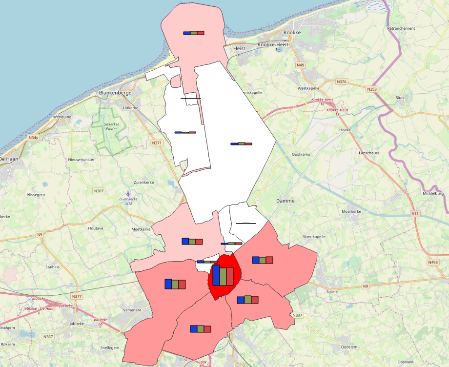

QGIS-MAP of Bruges

# RStudio

Based on found data I wanted to map the population of the different sexes in Bruges, compared to the total population.

I used three different files that I found on the open data website of the City Bruges: (https://www.brugge.be/opendata) - An KML file with the different Sectors in Bruges - Another KML file with the different districts - and an csv file with the population for Males and Females in the different districts

First I converted the KML files to shapefiles using QGIS. I was unable to find a quicker solution within rstudio.

```r
qtm(bruges_osm) +
  tm_shape(databruges) +
  tm_polygons(c("RateMales", "RateFemales","Density","20-29"),
    style="jenks",
    palette=list("Blues","Reds","Greens","Blues"),
    title=c("Rate Males Per Sector", "Rate Females per Sector","Density per Sector","# 50-59" ))
```

```
OpenStreetMapData read with read_osm is static, so not usable in view mode. Please use tm_basemap or tm_tiles, with the provider name set to "Esri.WorldStreetMap"
```

[interactive chart not shown]